# Forecasting Section 2.8

Seema Rani Kanuri

April 15, 2017

# Question 1:

For each of the following series (from the fma package), make a graph of the data. If transforming seems appropriate, do so and describe the effect.

## a. Monthly total of people on unemployed benefits (dole)

```r
summary(dole)
```

```
##    Min. 1st Qu.  Median    Mean 3rd Qu.    Max.
##    4742   20400   56760  221200  392600  856500
```

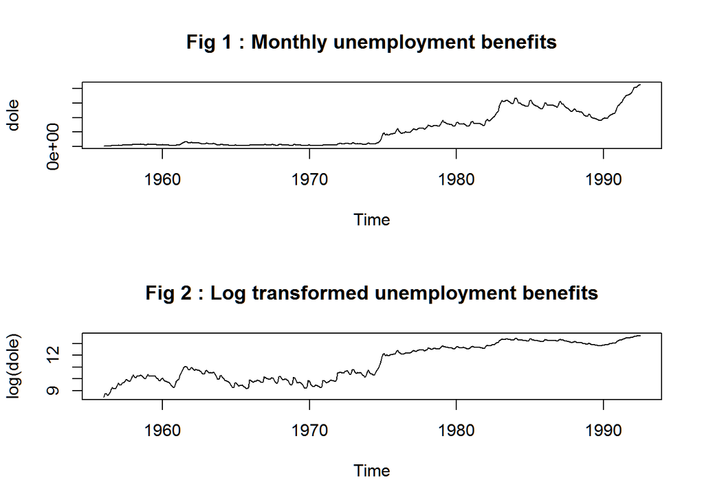

```r
par(mfrow=c(2,1))
plot(dole, main="Fig 1 : Monthly unemployment benefits")
plot(log(dole), main="Fig 2 : Log transformed unemployment benefits")
```

```r
lambda <- BoxCox.lambda(dole)
lambda
```

```
## [1] 0.3290922
```

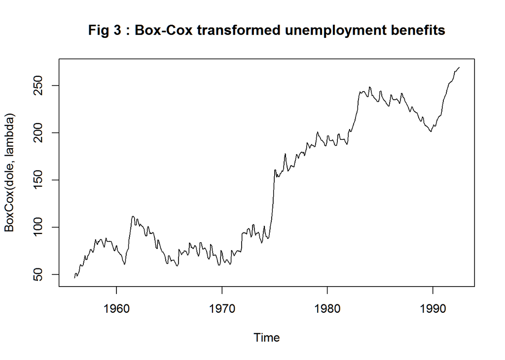

```r
par(mfrow=c(1,1))
plot(BoxCox(dole,lambda), main="Fig 3 : Box-Cox transformed unemployment benefits")
```

Transformations: Looking into the trasnformations it seems Monthly total of people on unemployed benefits (dole) of the Log and Box Cox transformation improve the distinction of the variation in the plots. Log transformation appears to be better transformation than the Box Cox.

### b. Monthly total of accidental deaths in the United States (January 1973-December 1978).

```r
#usdeaths - Accidental deaths in USA
summary(usdeaths)
```

```
##    Min. 1st Qu.  Median    Mean 3rd Qu.    Max.
##    6892    8089    8728    8788    9323   11320
```

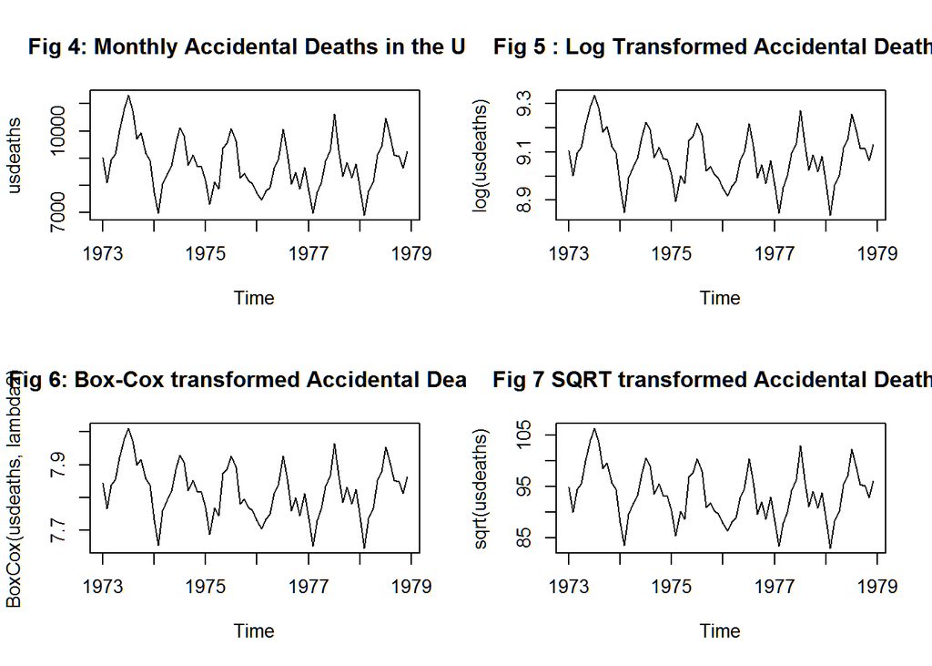

```r
par(mfrow=c(2,2))
plot(usdeaths, main="Fig 4: Monthly Accidental Deaths in the US")
plot(log(usdeaths), main="Fig 5 : Log Transformed Accidental Deaths")
lambda2 <- BoxCox.lambda(usdeaths)
plot(BoxCox(usdeaths,lambda2), main = "Fig 6: Box-Cox transformed Accidental Deaths")
plot(sqrt(usdeaths), main = "Fig 7 SQRT transformed Accidental Deaths")
```

```r
lambda2
```

```
## [1] -0.03363775
```

### Transformations:

Looking into the trasnformations it seems Monthly total of accidental deaths in the United States are similar variation in the accidental deaths

### c. Quarterly production of bricks (in millions of units) at Portland, Australia (March 1956-September 1994).

```r
#bricksq - Quarterly clay brick production

summary(bricksq)
```

```
##    Min. 1st Qu.  Median    Mean 3rd Qu.    Max.
##   187.0   338.5   428.0   408.8   490.5   589.0
```

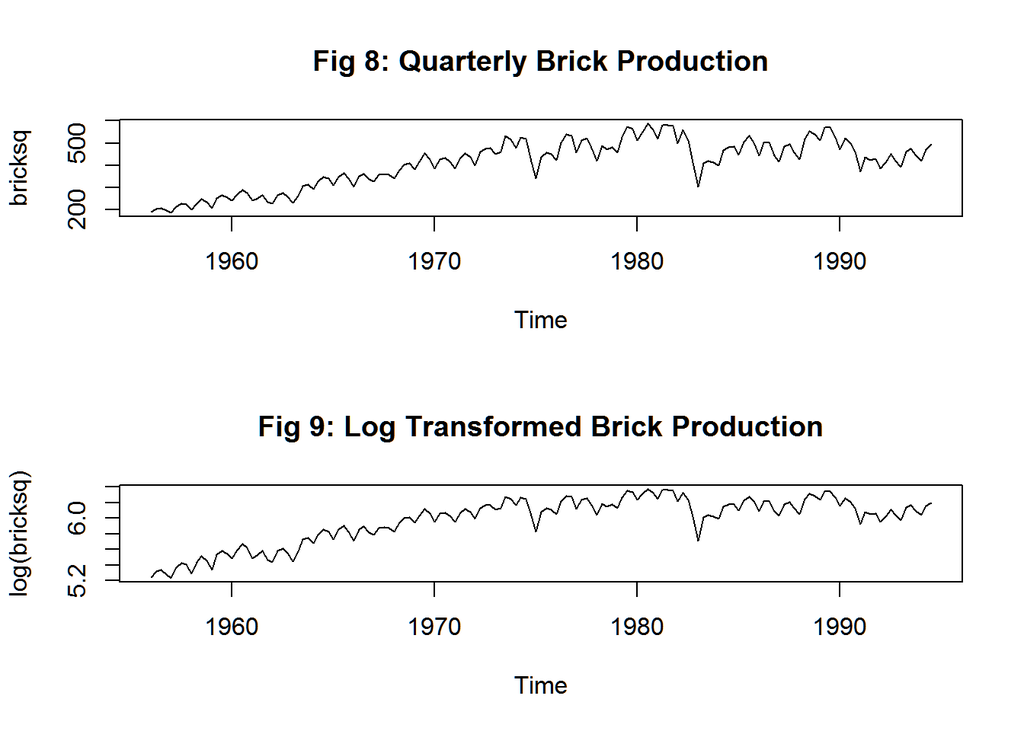

```r
par(mfrow=c(2,1))
plot(bricksq, main="Fig 8: Quarterly Brick Production")
plot(log(bricksq), main = "Fig 9: Log Transformed Brick Production")
```

```r
lambda3 <- BoxCox.lambda(bricksq)
lambda3
```

```
## [1] 0.2548929
```

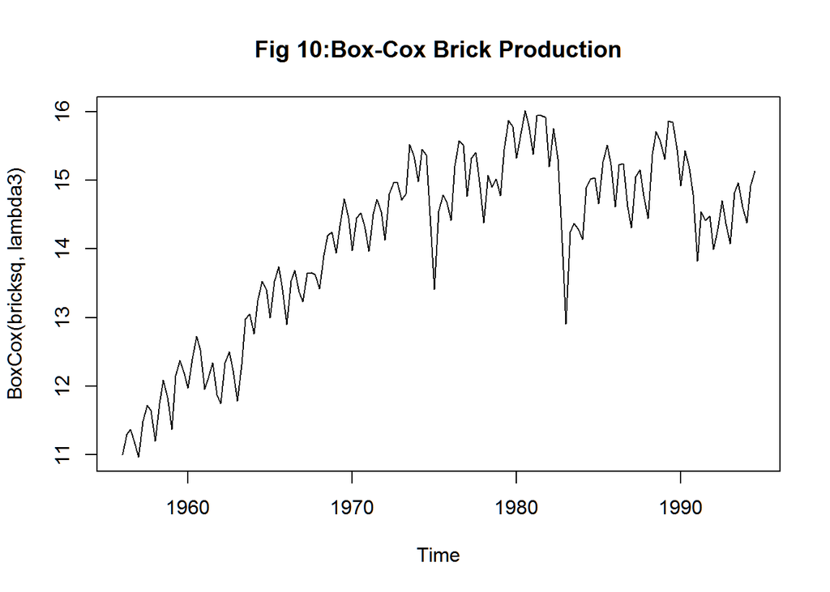

```r
plot(BoxCox(bricksq,lambda3), main = "Fig 10:Box-Cox Brick Production")
```

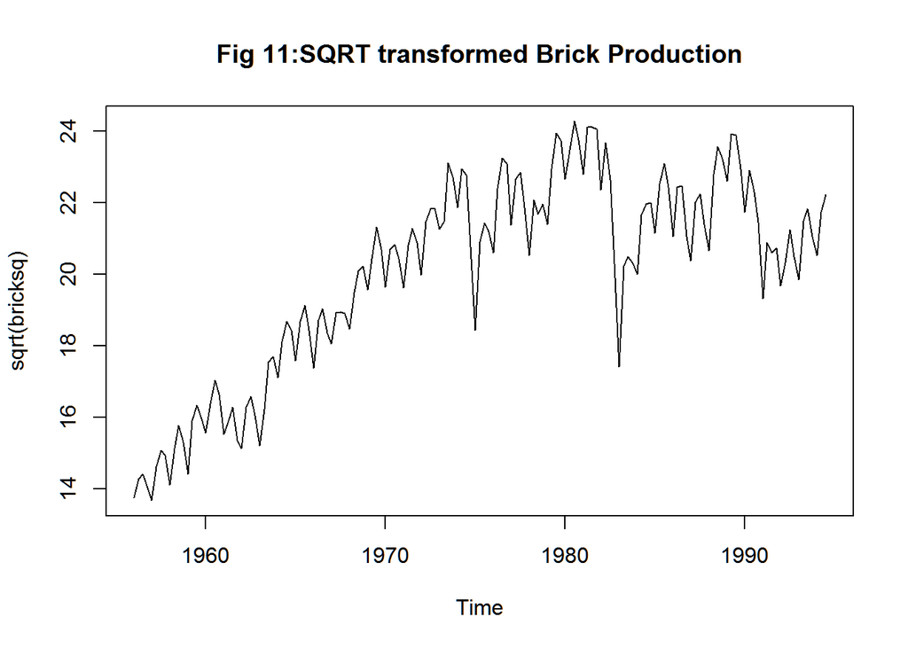

```r
plot(sqrt(bricksq), main = "Fig 11:SQRT transformed Brick Production")
```

### Transformations:

Looking into the trasnformations it seems Quarterly production of bricks (in millions of units) at Portland, Australia are similar to the accidentral deaths .

# Question 2:

Use the Dow Jones index (data set dowjones) to do the following

### a. Produce a time plot of the series.

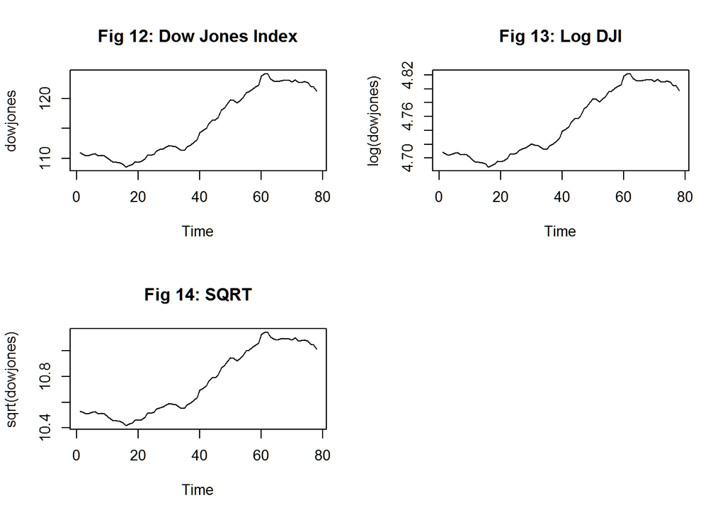

```r
par(mfrow=c(2,2))
plot(dowjones, main="Fig 12: Dow Jones Index")
plot(log(dowjones), main = "Fig 13: Log DJI")
plot(sqrt(dowjones), main = "Fig 14: SQRT")
```

## b. Produce forecasts using the drift method and plot them.

[figure not shown]

```r
dowjones_drift <- rwf(dowjones , h=10, drift=TRUE)
dowjones_drift_log <- rwf(log(dowjones), h = 10, drift = TRUE)
dowjones_drift_sqrt <- rwf(sqrt(dowjones), h =10, drift = TRUE)
par(mfrow=c(2,2))

plot(dowjones_drift,plot.conf=FALSE,main="Fig 15: Drift Method Dow Jones", ylab="Index",xlab="Year")
legend("topleft",lty=1, col=c(4),legend=c("SQRT"))
plot(dowjones_drift_log,plot.conf=FALSE,main="Fig 16: Log Method Dow Jones", ylab="Index",xlab="Year")
legend("topleft",lty=1, col=c(4),legend=c("Log"))
plot(dowjones_drift_sqrt,plot.conf=FALSE,main="Fig 17:SQRT Method Dow Jones", ylab="Index",xlab="Year")
legend("topleft",lty=1, col=c(4),legend=c("Drift"))
```

## c. Show that the graphed forecasts are identical to extending the line drawn between the first and last observations.

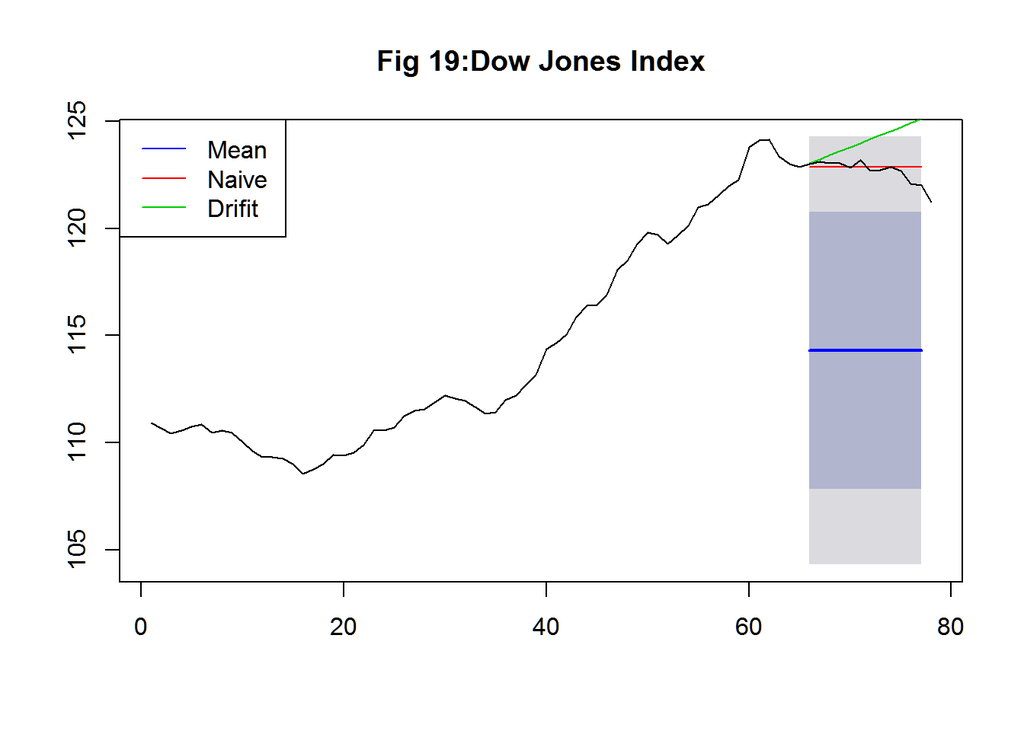

```r
dj_first_last <- window(dowjones, start=1, end=66-.1)
dj_first_last_mean <- meanf(dj_first_last,h=12)
dj_first_last_1 <- rwf(dj_first_last,h=12)
dj_first_last_2 <- rwf(dj_first_last,h=12, drift = TRUE)
plot(dj_first_last_mean, plot.conf=FALSE, main="Fig 19:Dow Jones Index", xlim=c(1,78))
lines(dj_first_last_1$mean,col=2)
lines(dj_first_last_2$mean,col=3)
lines(dowjones)
legend("topleft", lty=1, col=c(4,2,3), legend=c("Mean ","Naive","Drifit"))
```

## d. Try some of the other benchmark functions to forecast the same data set. Which do you think is best? Why?

[figure not shown]

```r
par(mfrow=c(1,1))
dowjones_drift <- rwf(dowjones , h=24, drift=TRUE)
dowjones_drift_mean <-meanf(dowjones, h=42)
dowjones_drift_naive <-naive(dowjones, h=42)

plot(dowjones_drift,plot.conf=FALSE,main="Fig 20: Drift Method Dow Jones", ylab="Index",xlab="Year")
lines(dowjones_drift_mean$mean, col=2)
lines(dowjones_drift_naive$mean, col=3)
legend("topleft",lty=1, col=c(4,2,3),legend=c("Mean Method","Naive Method","Drift"))
```

### Forecasts:

Compairing thr Mean and Naive method which are more static statistics the drift method shows good improvement probabily because of the upward/downward trend.

# Question 3:

## a. Produce some plots of the data in order to become familiar with it.

```r
head(ibmclose)
```

```
## Time Series:
## Start = 1
## End = 6
## Frequency = 1
## [1] 460 457 452 459 462 459
```

```r
summary(ibmclose)
```

```
##    Min. 1st Qu.  Median    Mean 3rd Qu.    Max.
##   306.0   387.0   494.0   478.5   549.0   603.0
```

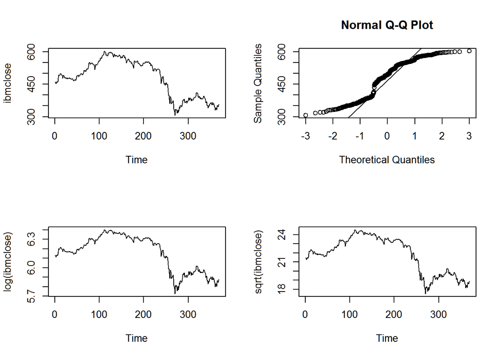

```r
par(mfrow=c(2,2))
plot(ibmclose)
qqnorm(ibmclose)
qqline(ibmclose)
plot(log(ibmclose))
plot(sqrt(ibmclose))
```

## b. Split the data into a training set of 300 observations and a test set of 69 observations.

```r
ibm_close_train <- window(ibmclose ,end=300)
ibm_close_test <- window(ibmclose ,start=301)
```

## c. Try various benchmark methods to forecast the training set and compare the results on the test set. Which method did best?

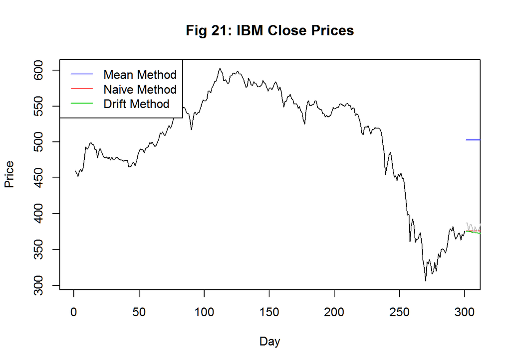

```r
par(mfrow=c(1,1))
ibm_close_avg <- meanf(ibm_close_train,h=54)$mean
ibm_close_naive <- naive(ibm_close_train ,h=54)$mean
ibm_close_drift <- rwf(ibm_close_train ,drift=TRUE,h=54)$mean

plot(ibm_close_train,main="Fig 21: IBM Close Prices",xlab="Day",ylab="Price")

lines(ibm_close_naive,col=2)
lines(ibm_close_avg,col=4)
lines(ibm_close_drift,col=3)
lines(ibm_close_test,col=8)

legend("topleft",lty=1,col=c(4,2,3),
  legend=c("Mean Method","Naive Method","Drift Method"))
```

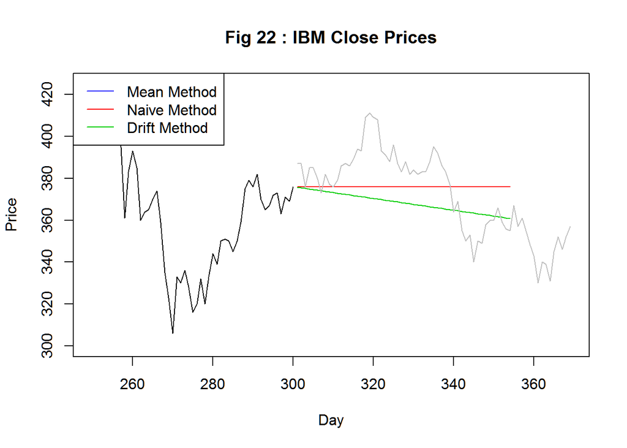

```r
plot(ibm_close_train,main="Fig 22 : IBM Close Prices", ylab="Price",xlab="Day", xlim=c(250,369), ylim=c(300,425))
lines(ibm_close_naive,col=2)
lines(ibm_close_avg,col=4)
lines(ibm_close_drift,col=3)
lines(ibm_close_test,col=8)

legend("topleft",lty=1,col=c(4,2,3),
  legend=c("Mean Method","Naive Method","Drift Method"))
```

### Forecasts:

Compairing thr Mean and Naive method which are more static statistics the drift method shows good improvement probabily because of the upward/downward trend.

# Question 4:

Consider the sales of new one-family houses in the USA, Jan 1973 - Nov 1995 (data set hsales).

## a. Produce some plots of the data in order to become familiar with it.

```r
head(hsales)
```

```
##      Jan Feb Mar Apr May Jun
## 1973  55  60  68  63  65  61
```

```r
summary(hsales)
```

```
##    Min. 1st Qu.  Median    Mean 3rd Qu.    Max.
##   24.00   44.00   53.00   52.29   59.00   89.00
```

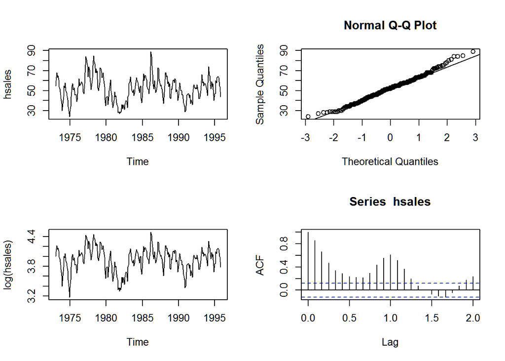

```r
par(mfrow=c(2,2))
plot(hsales)
qqnorm(hsales)
qqline(hsales)
plot(log(hsales))
acf(hsales)
```

## b. Split the hsales data set into a training set and a test set, where the test set is the last two years of data.

```r
hsales_timeseries <- ts(hsales,start=1,end=275)
hsales_timeseries_train <- window(hsales_timeseries,end=251)
hsales_timeseries_test <- window(hsales_timeseries,start=251)
```

## c. Try various benchmark methods to forecast the training set and compare the results on the test set. Which method did best?

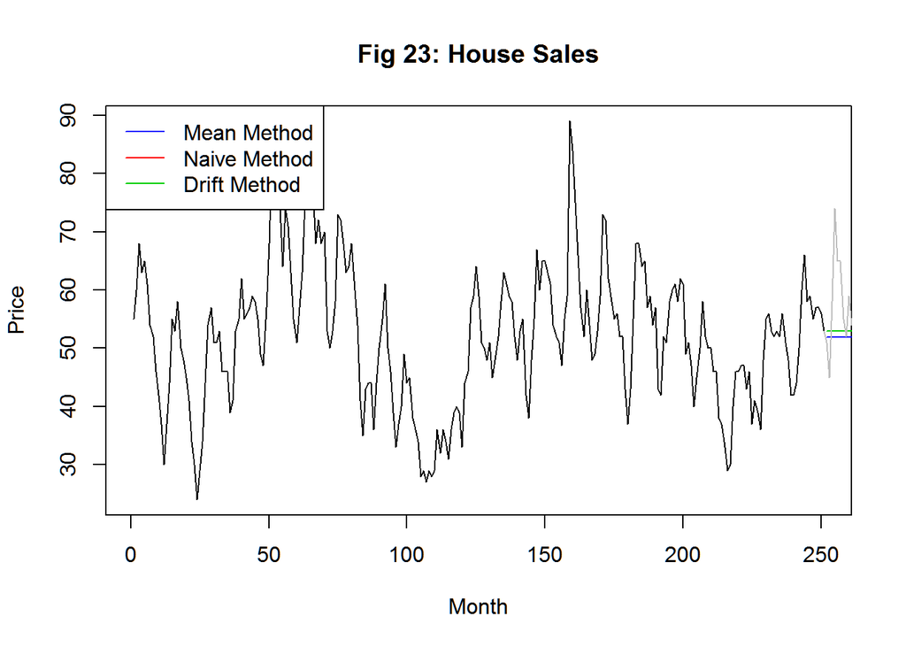

```r
par(mfrow=c(1,1))
hsales_timeseries_avg <- meanf(hsales_timeseries_train,h=24)$mean
hsales_timeseries_naive <- naive(hsales_timeseries_train,h=24)$mean
hsales_timeseries_drift <- rwf(hsales_timeseries_train,drift=TRUE,h=24)$mean

plot(hsales_timeseries_train,main="Fig 23: House Sales",xlab="Month",ylab="Price")

lines(hsales_timeseries_naive,col=2)
lines(hsales_timeseries_avg,col=4)
lines(hsales_timeseries_drift,col=3)
lines(hsales_timeseries_test,col=8)

legend("topleft",lty=1,col=c(4,2,3),
  legend=c("Mean Method","Naive Method","Drift Method"))
```

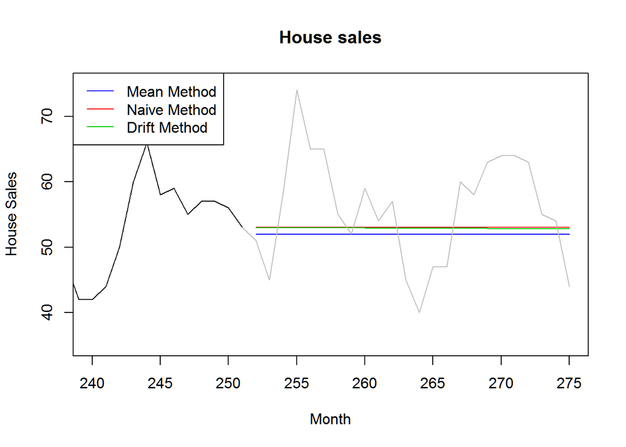

```r
plot(hsales_timeseries_train,main="House sales", ylab="House Sales",xlab="Month", xlim=c(240,275), ylim=c(35,75))

lines(hsales_timeseries_naive,col=2)
lines(hsales_timeseries_avg,col=4)
lines(hsales_timeseries_drift,col=3)
lines(hsales_timeseries_test,col=8)

legend("topleft",lty=1,col=c(4,2,3), legend=c("Mean Method","Naive Method","Drift Method"))
```